# PL Data Analysis

Programmation - M1 APE

## TABLE DES MATIERES

1. Présentation du sujet et contexte de l’étude
2. Démarche utilisée
3. Difficultées
4. Limites des modeles et du pouvoir prédictif
5. Ce qui pourrait être amélioré à l’avenir

## PRESENTATION DU SUJET ET CONTEXTE DE L’ETUDE

### Premier League

- Lorsque nous parlons de premier League, nous faisons référence au championnat national de Football Anglais.
- C’est le championnat le plus connu au monde, il est considéré comme le plus compliqué car aucune équipe n’a le monopole.

## DEMARCHES UTILISEES ET CODE

### Démarches utilisées

- Scraper différentes informations basiques : les points, victoires, les défaites à travers le temps.
- Scraper des informations en lien avec le championat actuel : Le budget
- Tenter d’appliquer des modèles statistiques et faire de la statistique descriptive.

## Code (1/7)

```python
from bs4 import BeautifulSoup
import urllib3
import re
import time
import requests
from collections import defaultdict
import numpy as np
import tqdm
import pandas as pd
from sklearn.linear_model import LogisticRegression
from sklearn.model_selection import train_test_split
from sklearn.metrics import accuracy_score
import matplotlib.pyplot as plt
import matplotlib.patches as patches
```

## Code (2/7)

### Première fonction

```python
urlpage_4 = 'https://www.skysports.com/premier-league-table/2023'
def get_page(urlpage_4,element,html_class):
    # avoir la page en html
    req_5 = urllib3.PoolManager()
    res_5 = req_5.request('GET', urlpage_4)
    row_html_5 = BeautifulSoup(res_5.data, 'html.parser')

    # Renvoie les éléments correspondant à la classe HTML dans une liste
    PL23 = row_html_5.find_all(element ,
    class_= html_class)
    return(PL23)

PL23 = str(get_page(urlpage_4, 'tr', 'row-body'))
```

## Code (3/7)

### Deuxième fonction

```python
#définir une fonction pour récolter de l'information sur les équipes
def lien_PL23 (PL23, team):
    team= team.title()
    teams = re.findall('<span class="team-name">(.*?)</span>',
    str(PL23))
    end = PL23.index("</tr>", start)
    team_data_20 = PL23[start:end]
    match_played= 38
    data = [int(s) for s in re.findall(r'<td.*?>(\d+)</td>', team_data_20)]
    points= data[0]
    wins= data [1]
    drawns= data [2]
    loses =data [3]
    goals_for = data [4]
    goals_against = data [5]
    team_stats20 = {'match_played': match_played,
    'position': position,'points': points,
                    'wins': wins,'loses': loses ,
                    'drawns':  drawns,'goals_for': goals_for,
        'goals_against':goals_against
    }
    return team_stats20
#on défini un dictionnaire
team_stats_20 = {}

#On créer une loop pour l'ensemble des équipes
for team in list_team_20:
    # obtenir les stats des équipes
    team_stats = stat23(PL19, team)
    # on met en dataframe les stats des équipes
    team_stats_df = pd.DataFrame(team_stats, index=[0])
    # On crée des noms de variables dans la dataframe
    team_stats_df['team'] = team
    team_stats_df['year'] = 2023
    # On ajoute au dictionnaire la dataframe
    team_stats_20[team] = team_stats_df
```

## Code (4/7)

### Deuxième fonction (bis)

#### Scraper d’une autre façon

```python
# on défini une fonction pour scraper d'une autre manière
def scrape_PL(year):
    url = f"https://www.skysports.com/premier-league-table/{year}"
    response = requests.get(url)
    if response.status_code != 200:
        print(f"Failed to retrieve data for {year}.")
        return None
    soup = BeautifulSoup(response.text, 'html.parser')
    table = soup.find('table', class_='standing-table__table')
    if table is None:
        print("Failed to find the standings table.")
        return None

    #On crée une boucle pour définir chaque variables dans le tableau
    standings_data = []
    for row in table.find_all('tr')[1:]:
        columns = row.find_all('td')
        team_name = columns[1].text.strip()
        matches_played = int(columns[2].text.strip())
        wins = int(columns[3].text.strip())
        draws = int(columns[4].text.strip())
        losses = int(columns[5].text.strip())
        goals_for = int(columns[6].text.strip())
        goals_against = int(columns[7].text.strip())
        goal_difference = int(columns[8].text.strip())
        points = int(columns[9].text.strip())
        #On nome ces variables
        standings_data.append({
            'Team': team_name,
            'Matches Played': matches_played,
            'Wins': wins,
            'Draws': draws,
            'Losses': losses,
            'Goals For': goals_for,
            'Goals Against': goals_against,
            'Goal Difference': goal_difference,
            'Points': points
        })

    return standings_data
```

## Code (5/7)

### Troisième fonction

```python
def stat23(standings, year):
    team_stats_20 = {}
    for team_data in standings:
        team_name = team_data['Team']
        stats = extract_team_stats_single(team_data, year)
        team_stats_df = pd.DataFrame(stats, index=[0])
        team_stats_df['team'] = team_name
        team_stats_df['year'] = year
        team_stats_20[team_name] = team_stats_df

    if not team_stats_20:
        print("No data extracted.")
        return None

    return pd.concat(team_stats_20.values(), ignore_index=True)
```

## Code (6/7)

### Quatrième fonction

```python
def extract_team_stats_single(team_data, year):
    match_played = team_data['Matches Played']
    points = team_data['Points']
    wins = team_data['Wins']
    losses = team_data['Losses']
    draws = team_data['Draws']
    goals_for = team_data['Goals For']
    goals_against = team_data['Goals Against']

    team_stats = {
        'year': year,
        'team': None,
        'match_played': match_played,
        'position': None,
        'points': points,
        'wins': wins,
        'loses': losses,
        'drawns': draws,
        'goals_for': goals_for,
        'goals_against': goals_against
    }

    return team_stats

year = 2023
standings = scrape_PL(year)
if standings:
    team_stats_20 = stat23(standings, year)
    print(team_stats_20)
```

## Code (7/7)

### Cinquième fonction

```python
#On défini l'url du site  où l'on trouve le budget pour chaque équipe
url_7 = "https://sportune.20minutes.fr/sport-business/football/les-budgets-des-clubs-de-la-premier-league-2023-2024-312241/2"

#On crée une fonction pour scraper l'url en faisant attention de se renomer
def scrape_premier_league_budgets(url):
    user_agent = {'User-Agent':'Mozilla/5.0 (Windows NT 10.0; Win64; x64) AppleWebKit/537.36 (KHTML, like Gecko) Chrome/122.0.0.0 Safari/537.36'}

    res = requests.get(url, headers=user_agent)
    if res.status_code != 200:
        print("Failed to retrieve data.")
        return None

    content = res.text
    soup = BeautifulSoup(content, "lxml")
    contents = re.findall('<tbody>.*?\n</tbody>\n</table>', str(soup), re.DOTALL)

    #On extrait les données que l'on veut
    all_headers = []
    for html_content in contents:
        html_soup = BeautifulSoup(html_content, 'html.parser')
        headers = html_soup.find_all("th")
        all_headers.extend(headers)

    Titles = [i.text for i in all_headers]
    df = pd.DataFrame(columns=Titles)

    #On ajoute les données dans la liste rows_data
    all_rows = []
    for html_content in contents:
        html_soup = BeautifulSoup(html_content, 'html.parser')
        rows = html_soup.find_all("tr")
        rows_data = []
        for row in rows:
            cells = row.find_all("td")
            cell_data = [cell.get_text(strip=True) for cell in cells]
            rows_data.append(cell_data)
        all_rows.extend(rows_data)

    if all_rows:
        all_rows.pop(-1)
    #On crée un dataframe pandas
    df = pd.concat([df, pd.DataFrame(all_rows, columns=Titles)], ignore_index=True)
    return df
```

## Diffucltés rencontrées (1/3)

```python
budgets_df = scrape_premier_league_budgets(url)
#Renommer la colonne 'team' de team_stats_20 en 'Club' pour faciliter la fusion
team_stats_20 = team_stats_20.rename(columns={'team': 'Club'})
```

## Difficultés rencontrées (2/3)

[output not shown]

## Difficultés rencontrées (2/3)

### BIS

```python
team_stats_20.replace({'Tottenham Hotspur': 'Tottenham',
                       'Nottingham Forest **': 'Nottingham Forest',
                       'Everton *': 'Everton',
                       'West Ham United': 'West Ham',
                       'Wolverhampton Wanderers': 'Wolverhampton',
                       'Brighton and Hove Albion': 'Brighton',
                       'Newcastle United': 'Newcastle'}, inplace=True)
```

## Difficultés rencontrées (3/3)

```python
# Suppression des caractères indésirables et les convertir en valeurs numériques
merged_df['Budget'] = pd.to_numeric(merged_df['Budget'].str.replace('M€', '')) * 1000000

# Affichage du DataFrame mis à jour
print(merged_df)
```

```
##     year               Club  match_played  ... goals_for  goals_against     Budget
## 0   2023            Arsenal            30  ...        72             24  525000000
## 1   2023          Liverpool            29  ...        67             27  690000000
## 2   2023    Manchester City            30  ...        67             29  800000000
## 3   2023        Aston Villa            31  ...        63             46  220000000
## 4   2023          Tottenham            30  ...        62             44  550000000
## 5   2023  Manchester United            29  ...        40             40  720000000
## 6   2023           West Ham            31  ...        50             55  290000000
## 7   2023          Newcastle            30  ...        64             52  305000000
## 8   2023           Brighton            30  ...        51             46  200000000
## 9   2023      Wolverhampton            30  ...        43             47  185000000
## 10  2023        Bournemouth            30  ...        44             53  160000000
## 11  2023            Chelsea            28  ...        49             47  600000000
## 12  2023             Fulham            31  ...        47             50  155000000
## 13  2023     Crystal Palace            30  ...        34             50  200000000
## 14  2023          Brentford            31  ...        42             55  175000000
## 15  2023            Everton            30  ...        31             42  230000000
## 16  2023  Nottingham Forest            31  ...        39             53  120000000
## 17  2023         Luton Town            31  ...        43             64   90000000
## 18  2023            Burnley            31  ...        32             66  125000000
## 19  2023   Sheffield United            29  ...        27             77  145000000
##
## [20 rows x 11 columns]
```

## Prédiction (1/4)

```python
from sklearn.linear_model import LinearRegression
#Debut de la regression linéaire
X = merged_df[['wins', 'loses', 'drawns', 'goals_for', 'goals_against', 'Budget']]
y = merged_df['points']
X_train, X_test, y_train, y_test = train_test_split(X, y, test_size=0.2, random_state=42)
model = LinearRegression()
model.fit(X_train, y_train)
```

```
LinearRegression()
```

```python
# On souhaite obtenir les performances du modèle sur les données de test
score = model.score(X_test, y_test)
print("Coefficient de détermination R^2 :", score)
```

```
## Coefficient de détermination R^2 : 0.9867073492993162
```

## Prédiction (2/4)

```
##                  Generalized Linear Model Regression Results
## ==============================================================================
## Dep. Variable:                 points   No. Observations:                   20
## Model:                            GLM   Df Residuals:                       13
## Model Family:                 Poisson   Df Model:                            6
## Link Function:                    Log   Scale:                          1.0000
## Method:                          IRLS   Log-Likelihood:                -57.466
## Date:              jeu., 04 avr. 2024   Deviance:                       5.3477
## Time:                        10:19:29   Pearson chi2:                     5.16
## No. Iterations:                     4   Pseudo R-squ. (CS):             0.9975
## Covariance Type:            nonrobust
## =================================================================================
##                     coef    std err          z      P>|z|      [0.025      0.975]
## ---------------------------------------------------------------------------------
## const             3.1231      1.902      1.642      0.101      -0.605       6.851
## wins              0.0630      0.063      0.993      0.320      -0.061       0.187
## loses            -0.0276      0.063     -0.439      0.660      -0.151       0.095
## drawns            0.0048      0.066      0.073      0.942      -0.124       0.134
## goals_for        -0.0017      0.007     -0.251      0.802      -0.015       0.012
## goals_against     0.0042      0.007      0.614      0.539      -0.009       0.018
## Budget        -1.326e-10    3.1e-10     -0.428      0.668    -7.4e-10    4.74e-10
## =================================================================================
```

## Prédiction (2/4)

### BIS

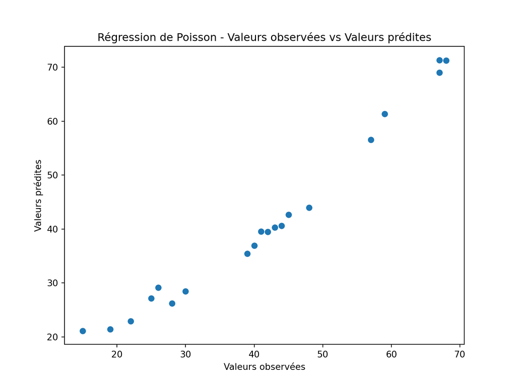

## Prédiction (3/4)

```python
# Nombre de matchs à prédire
nb_matchs = 38
# Coefficients du modèle
coefficients = poisson_results.params
# Prédictions des points pour chaque équipe
predicted_points = poisson_results.predict(X)
# Calcul des points supplémentaires pour chaque équipe en fonction des résultats de matchs prévus
predicted_wins_points = coefficients['wins'] * nb_matchs * 3
predicted_draws_points = coefficients['drawns'] * nb_matchs
predicted_losses_points = 0  # Les défaites ne contribuent pas aux points
# Ajouter les points supplémentaires aux prédictions de points
predicted_points += predicted_wins_points + predicted_draws_points + predicted_losses_points
# Classer les équipes en fonction des points prédits
predicted_points_ranking = predicted_points.sort_values(ascending=False)
```

## Prédiction (3/4)

### BIS

```
##                  Team  Predicted Points
## 1           Liverpool         78.724717
## 0             Arsenal         78.636982
## 2     Manchester City         76.360996
## 3         Aston Villa         68.709485
## 4           Tottenham         63.930149
## 5   Manchester United         51.328679
## 6            West Ham         50.059561
## 7           Newcastle         47.965649
## 8            Brighton         47.633419
## 10        Bournemouth         46.927692
## 9       Wolverhampton         46.880738
## 11            Chelsea         44.265629
## 12             Fulham         42.823229
## 15            Everton         36.528046
## 13     Crystal Palace         35.793462
## 16  Nottingham Forest         34.535113
## 14          Brentford         33.564200
## 17         Luton Town         30.291486
## 18            Burnley         28.791069
## 19   Sheffield United         28.467689
```

## Prédiction (4/4)

[output not shown]

```
## (-1.0999999848181172, 1.0999999982924864, -1.0999999900789188, 1.0999999994670506)
```

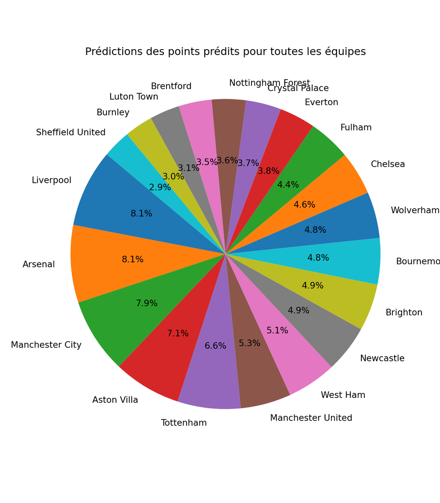

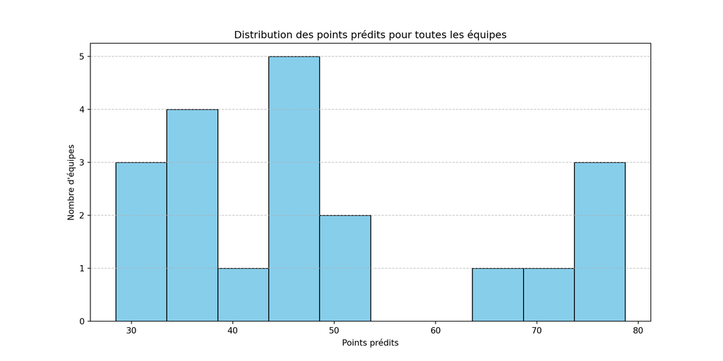

## Répartition des équipes

### Conforme à la réalité

## LIMITES

- Cela peut s’expliquer par plusieurs facteurs :
- Des caractéristiques intrinsèques aux joueurs sont inobservables.
- Le nombre de variables pouvant être prises en compte est beaucoup trop grand.
- La composition des équipes est changeante.

## PISTES D’AMELIORATION

- Pour une analyse plus poussée et pourquoi par une prédiction plus ‘sensée’, il serait intéressant de :
- Multiplier le nombre et la variété des donneés
- Essayer d’autres modèles statistiques
- Il serait intéressant d’automatisé le code de façon à ce qu’il intègre automatiquement des nouvelles données dès que celle-ci seraient disponibles.